# Getting started

Tutorial 1: guided tutorial

Dr Massimiliano Canzi

## Today

We go through this tutorial together. Open RStudio and type along.

1. Install `{konstats}`, the package of this course
2. Look at `{simling}`, where the data sets of the course come from
3. Practise the R basics from lecture 1, on linguistic data

# 1. konstats

## 1.1 What konstats is

`{konstats}` is the companion package of this course. It gives you:

- every package the course uses, installed with one command
- the list of lectures, with a link to each set of slides
- the exercise sheets of the tutorials
- a template for the weekly assignments

## 1.2 A folder for the course

Keep everything for the course in one folder, as an RStudio project:

*File > New Project > New Directory > New Project*

Call it `statistics`, for example. When you open the project, R works inside that folder, so your files are always where R looks for them.

## 1.3 Installing konstats

`{konstats}` is on R-universe. Type this in the `Console`, once:

```r
install.packages("konstats", repos = c("https://mcanzi.r-universe.dev",
                                       "https://cloud.r-project.org"))
konstats::install_course("statistics")
```

The second line installs every package the course uses, from the `tidyverse` and `swirl` of lecture 1 to `{simling}`. It takes a few minutes the first time.

If R asks whether to update other packages, choose `1: All`. If it asks about installing from source, answer `no`.

## 1.4 Is your computer ready?

Load the package, and check your setup:

```r
library(konstats)
check_setup("statistics")
```

```
── Setup for Statistics ──
```

```
✔ All 10 packages are installed.
```

If a package is missing, the message tells you which, and what to run. Run `check_setup()` again whenever code from the course fails on your computer.

## 1.5 Lectures and slides

The lectures follow the textbook by Winter (2019), with new examples and data sets. `lectures()` lists the lectures, with their chapters of the book and data sets:

```r
lectures("statistics")[, c("number", "topic", "winter", "datasets")]
```

```
# A tibble: 13 × 4
   number topic                  winter datasets
    <int> <chr>                  <chr>  <chr>
 1      1 Course introduction    1      <NA>
 2      2 Data wrangling         2      penguins
 3      3 Descriptive statistics 3      penguins
 4      4 Linear models          4      penguins
 5      5 Transformations        5      formants, language_attitudes,…
 6      6 Multiple regression    6      megastudy
 7      7 Categorical predictors 7      formants, korean_stops, rhyth…
 8      8 Interactions           8      cantonese_tone_merger, freq_l…
 9      9 Significance testing   9      accent, style_voicing, vowel_…
10     10 Mixed models 1         14     lexical_decision
# ℹ 3 more rows
```

`slides()` opens the slides of a lecture in your browser, by number or by topic:

```r
slides(2)
slides("mixed models 1")
```

## 1.6 Exercise sheets

From next week, each tutorial has an exercise sheet: an R Markdown file with the exercises and an empty code chunk for each answer. `tutorials()` lists the sheets, and `get_tutorial()` copies one into your project folder:

```r
tutorials("statistics")
get_tutorial(2, ".")
```

You write your answers in your copy. If the sheet is already in the folder, `get_tutorial()` stops with an error, so your answers are never overwritten.

## 1.7 Handing in homework

Tutorials 2, 4, 8, 10 and 12 end with a weekly assignment, which you hand in on Ilias.

To start the file you hand in:

*File > New File > R Markdown > From Template > Weekly assignment (konstats)*

It has a section for each exercise.

# 2. simling

## 2.1 What simling is

The data are simulated, so we know the true values behind them. You can check whether your analysis finds them.

`install_course()` installed it already. Load it like any other package:

```r
library(simling)
```

## 2.2 Finding a data set

`simling_datasets()` lists all of them, with their branch, language, size, response and topic:

```r
simling_datasets()
```

```
# A tibble: 56 × 7
   name               branch    language   rows columns response topic
   <chr>              <fct>     <chr>     <int>   <int> <chr>    <chr>
 1 formants           Phonetics <NA>        120       5 continu… Norm…
 2 vowel_voicing      Phonetics English     120       2 continu… Two …
 3 speech_styles      Phonetics <NA>        150       2 continu… Cate…
 4 style_voicing      Phonetics <NA>        160       3 continu… Cate…
 5 vowel_duration     Phonetics <NA>        384       4 continu… Mixe…
 6 korean_stops       Phonetics Korean     1440       8 continu… Clus…
 7 price_f2           Phonetics English …  2200       6 traject… GAMs…
 8 mandarin_tones     Phonetics Mandarin   4224       8 traject… Cont…
 9 vot_identification Phonetics English,…  1224       6 binomia… Psyc…
10 hungarian_harmony  Phonology Hungarian  4200       6 binary   Mixe…
# ℹ 46 more rows
```

## 2.3 A first data set

`vowel_voicing` comes from a production study: vowels before voiceless consonants (*beat*) and before voiced ones (*bead*).

```r
head(vowel_voicing)
```

```
# A tibble: 6 × 2
  voicing   duration
  <fct>        <dbl>
1 voiceless      166
2 voiceless       96
3 voiceless      106
4 voiceless      112
5 voiceless      101
6 voiceless      101
```

Every data set has a help page, with what each column means and the true model behind the data:

```r
?vowel_voicing
```

## 2.4 A first plot

A preview of lectures 2 and 3: you do not need to understand this code yet.

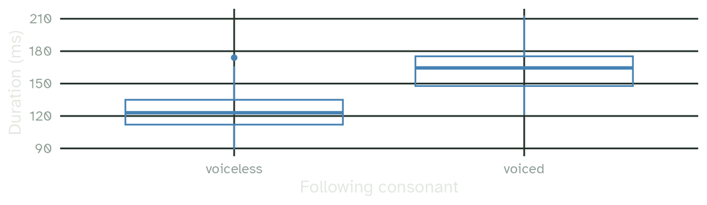

```r
library(tidyverse)
ggplot(vowel_voicing, aes(x = voicing, y = duration)) +
  geom_boxplot(fill = NA, colour = "steelblue") +
  labs(x = "Following consonant", y = "Duration (ms)")
```

## 2.5 The true values

The help page says that the true means are 120 ms before voiceless and 160 ms before voiced consonants. The means in the data:

```r
tapply(vowel_voicing$duration, vowel_voicing$voicing, mean)
```

```
voiceless    voiced
 124.3000  162.0667
```

They are close to the true values, but not the same: the data are one random sample of 60 vowels per group. We come back to this in lecture 9.

# 3. R basics

## 3.1 R as a calculator

Open a new script (*File > New File > R Script*), and run each line with `Ctrl + Enter` (`Cmd + Enter` on a Mac):

```r
2 + 2
```

```
[1] 4
```

```r
(3 + 2) * 4
```

```
[1] 20
```

```r
160 - 120    # how much longer, in ms?
```

```
[1] 40
```

Everything after `#` is a comment. Save the script in your project folder.

## 3.2 Objects

`<-` stores a value in an object:

```r
voiceless <- 120
voiced <- 160
voiced - voiceless
```

```
[1] 40
```

Both objects now appear in the `Environment`. Names are case sensitive: `Voiced` is a different name, and no object has it.

## 3.3 Vectors

`c()` combines values into a vector. Here are five vowel durations, in ms:

```r
durations <- c(166, 96, 106, 112, 101)
durations / 1000    # in seconds
```

```
[1] 0.166 0.096 0.106 0.112 0.101
```

```r
mean(durations)
```

```
[1] 116.2
```

What is the shortest and the longest duration? Try `min()` and `max()`.

## 3.3 Solution

```r
min(durations)
```

```
[1] 96
```

```r
max(durations)
```

```
[1] 166
```

## 3.4 Indexing

Square brackets pick elements by position:

```r
durations[1]
```

```
[1] 166
```

```r
durations[2:4]
```

```
[1]  96 106 112
```

```r
durations[-1]
```

```
[1]  96 106 112 101
```

How do you get the last duration, and the first and the last together?

## 3.4 Solution

```r
durations[5]
```

```
[1] 101
```

```r
durations[c(1, 5)]
```

```
[1] 166 101
```

## 3.5 Logical vectors

A comparison gives `TRUE` or `FALSE` for every element:

```r
durations > 110
```

```
[1]  TRUE FALSE FALSE  TRUE FALSE
```

```r
durations[durations > 110]
```

```
[1] 166 112
```

How many of the five vowels are longer than 110 ms? And what proportion?

## 3.5 Solution

`TRUE` counts as 1 and `FALSE` as 0:

```r
sum(durations > 110)
```

```
[1] 2
```

```r
mean(durations > 110)
```

```
[1] 0.4
```

## 3.6 Data frames

`vowel_voicing` is a data frame (a tibble): a table whose columns are vectors of the same length.

```r
nrow(vowel_voicing)
```

```
[1] 120
```

```r
vowel_voicing[1:3, ]
```

```
# A tibble: 3 × 2
  voicing   duration
  <fct>        <dbl>
1 voiceless      166
2 voiceless       96
3 voiceless      106
```

`$` takes out one column, as a vector:

```r
mean(vowel_voicing$duration)
```

```
[1] 143.1833
```

## 3.7 Your turn: one column

Using `vowel_voicing$duration`:

1. How long is the longest vowel in the data?
2. How many vowels are longer than 150 ms?
3. What proportion of vowels is longer than 150 ms?

## 3.7 Solution

```r
max(vowel_voicing$duration)
```

```
[1] 213
```

```r
sum(vowel_voicing$duration > 150)
```

```
[1] 49
```

```r
mean(vowel_voicing$duration > 150)
```

```
[1] 0.4083333
```

## 3.8 Factors

`voicing` is a factor: a column of categories, with a fixed set of levels.

```r
levels(vowel_voicing$voicing)
```

```
[1] "voiceless" "voiced"
```

```r
table(vowel_voicing$voicing)
```

```
voiceless    voiced
       60        60
```

The first level, `voiceless`, is the reference level. It matters from lecture 7, when categories go into a model. In `{simling}`, the first level is always the baseline condition.

## 3.9 Functions and missing values

Functions take arguments inside their brackets:

```r
round(mean(vowel_voicing$duration), digits = 1)
```

```
[1] 143.2
```

`NA` is a missing value, for example a vowel whose recording failed:

```r
with_gap <- c(166, NA, 106)
mean(with_gap)
```

```
[1] NA
```

```r
mean(with_gap, na.rm = TRUE)
```

```
[1] 136
```

## 3.10 Getting help

- `?mean` opens the help page of `mean()`, and `?vowel_voicing` works for data sets too. The examples at the bottom of a help page can be run as they are.
- An error message pasted into a search engine usually finds someone who had the same problem.

Cite the software you use:

```r
citation()             # R
citation("simling")    # a package
```

## Before next week

Start `swirl`, the interactive lessons from lecture 1, and choose the course *R Programming*:

```r
library(swirl)
swirl()
```

Next week: data wrangling with the tidyverse. Copy the exercise sheet into your project before the tutorial:

```r
get_tutorial(2, ".")
```

## Reading

This tutorial goes with chapter 1 of Winter (2019).

Winter, B. (2019). *Statistics for linguists: An introduction using R*. Routledge. https://doi.org/10.4324/9781315165547

## Slides and code

[figure not shown]

These slides

mcanzi.de/statistics/tutorials/01_getting_started.html

All the code (R Markdown)

mcanzi.de/statistics/tutorials/01_getting_started.Rmd